# ds202_lab2

Brian Bates (bkbates),

2/5/2019

**Question 1: What is the overall number of chocolate bars rated?**  
The average rating for a choclate bar is 3.19. The total number of chocolate bars rated is 1852.

```r
mean(choco$Rating)
```

```
## [1] 3.19101
```

```r
dim(choco)[1]
```

```
## [1] 1852
```

**Question 2: How does the number of ratings depend upon the year?**  
There was a trend of increasing number of reviews from 2006-2015, following a sharp decline in 2017.

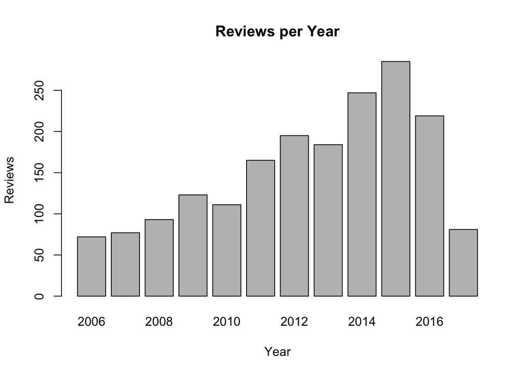

```r
c <- table(choco$Review.Date)
barplot(c, main="Reviews per Year", xlab="Year", ylab="Reviews")
```

**Questin 3: How do ratings compare across different company locations?**

```r
t = table(choco$Company.Location)
order(t, decreasing=TRUE)
```

```
##  [1] 58 19  8 57 30 15  3  5 55 20  4 51 10 25 59  7 31 33 37 40 13 60 23
## [24] 47  2 11 29 42  1 24 32 14 39 50 54 17 28 35 36 44 46 56 22 26 43 45
## [47] 48 49  6  9 18 27 52 12 16 21 34 38 41 53 61
```

```r
first = t[58]
first
```

```
## U.S.A.
##    787
```

```r
second = t[19]
second
```

```
## France
##    158
```

```r
third = t[8]
third
```

```
## Canada
##    132
```

The companies with the most ratings, in decreasing order, are: U.S.A., France, and Canada. We can run summary statistics across the ratings of each company but a better approach is to visualize it with a boxplot.

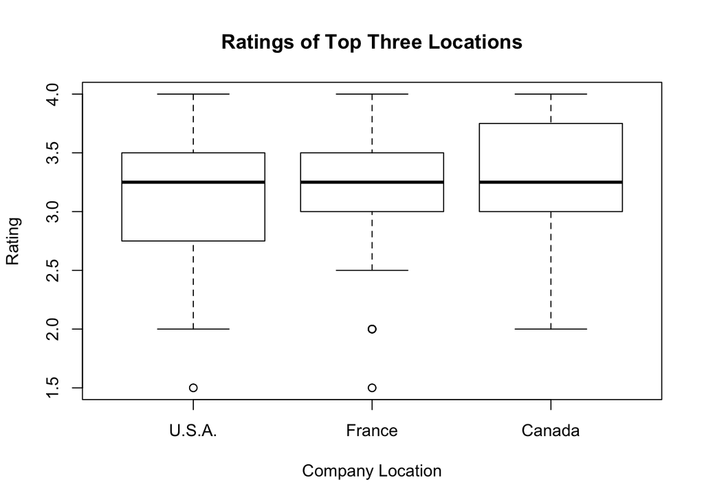

```r
# Construct a new data frame holding only the data of the top three companies
df = choco[choco$Company.Location == "U.S.A." | choco$Company.Location == "France" | choco$Company.Location == "Canada", ]

# Refactor the Company.Location.
df$Company.Location = factor(df$Company.Location, levels=c("U.S.A.", "France", "Canada"))

# Boxplot of ratings for each company provides a visual representation of the summary data
boxplot(df$Rating ~ df$Company.Location, main="Ratings of Top Three Locations", xlab="Company Location", ylab="Rating")
```

**Question 4 & 5: Brainstorm and write down an interesting question that can be answer from the dataset. The question should not duplicate the questions above.**  
As an extra it is interesting to see where the the cocoa percent was for the top three company locations in the context of individual question two.

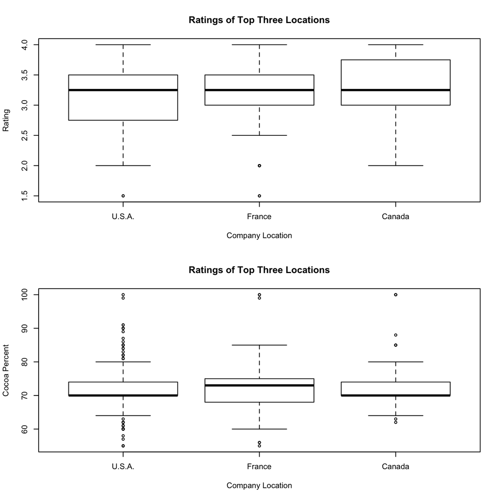

```r
m = matrix(data=c(1, 1, 1, 1, 2, 2, 2, 2), nrow=8, ncol = 1, byrow=TRUE)
layout(m)

boxplot(df$Rating ~ df$Company.Location, main="Ratings of Top Three Locations", xlab="Company Location", ylab="Rating")
boxplot(df$Cocoa.Pct ~ df$Company.Location, main="Ratings of Top Three Locations", xlab="Company Location", ylab="Cocoa Percent")
```

```r
# All USA data
usa.data = choco[(choco$Company.Location == "U.S.A."), ]

# Top 10 companies in the USA
(highest.levels = levels(reorder(usa.data$Company, usa.data$Rating))[1:10])
```

```
##  [1] "Jacque Torres"              "Love Bar"
##  [3] "Shark's"                    "Marsatta"
##  [5] "Cacao Atlanta"              "Chocolate Alchemist-Philly"
##  [7] "Chocovivo"                  "Garden Island"
##  [9] "Lake Champlain (Callebaut)" "Oakland Chocolate Co."
```